# BIOS 611 HW3 Exploratory Analysis, tibbles, and data import (Chapters 7, 10, and 11.2)

# Exercise 6

1. Compare and contrast the following operations on a `data.frame` and equivalent tibble. What is different? Why might the default data frame behaviours cause you frustration?

   ```r
   df <- data.frame(abc = 1, xyz = "a")
   df$x
   df[, "xyz"]
   df[, c("abc", "xyz")]
   ```

   Answer: The default data.frame treats “a” as a factor with one level. A tibble treats it as a character variable as was likely intended by using quotes. Also using the $ operator with a data.frame will partially match, potentially choosing a different column than you intended if there are multiple columns that satisfy the partial match. Tibbles are stricter about subsetting and always return a tibble.
2. If you have the name of a variable stored in an object, e.g. `var <- "mpg"`, how can you extract the reference variable from a tibble? For example, you simply could have done `mtcars$mpg`. But later on if you want to extract other variables as well, say `cyl`, which is given as an object `var`, you don’t want to manually put the variable names by typing `mtcars$cyl`. How would you do this without explicitly writing `"mpg"` or `"cyl"`?

   Answer: You can use double brackets. newdata[[var]]

   ```r
   newdata <- as.tibble(mtcars)
   var <- "mpg"

   newdata[[var]]
   ```

   ```
   ##  [1] 21.0 21.0 22.8 21.4 18.7 18.1 14.3 24.4 22.8 19.2 17.8 16.4 17.3 15.2
   ## [15] 10.4 10.4 14.7 32.4 30.4 33.9 21.5 15.5 15.2 13.3 19.2 27.3 26.0 30.4
   ## [29] 15.8 19.7 15.0 21.4
   ```

3. Practice referring to non-syntactic names in the following data frame by:

   ```r
   newdata = tibble(`1` = rnorm(1:5), `2` = `1` + runif(5))
   ```

   1. Extracting the variable called `1`.

   Answer:

   ```r
   newdata$`1`
   ```

   ```
   ## [1]  0.07730312 -0.29686864 -1.18324224  0.01129269  0.99160104
   ```

   2. Plotting a scatterplot of `1` vs `2`.

   Answer:

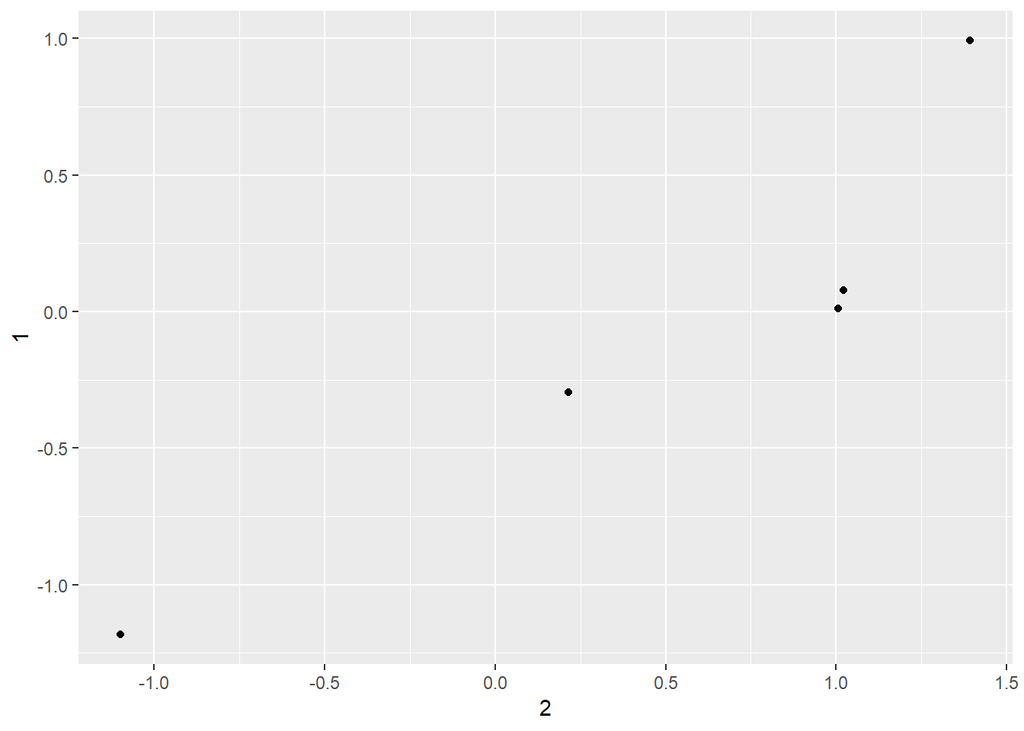

   ```r
   ggplot(newdata,aes(x=`2`,y=`1`))+geom_point()
   ```

   3. Creating a new column called `3` which is `2` divided by `1`.

   Answer:

   ```r
   newdata1 <- newdata%>%mutate(`3`=`2`/`1`)
   ```

   4. Renaming the columns to `one`, `two` and `three`.

   Answer:

   ```r
   newdata1%>%rename(one=`1`,two=`2`,three=`3`
                     )
   ```

   ```
   ## # A tibble: 5 x 3
   ##       one    two   three
   ##     <dbl>  <dbl>   <dbl>
   ## 1  0.0773  1.02   13.2
   ## 2 -0.297   0.215  -0.724
   ## 3 -1.18   -1.10    0.928
   ## 4  0.0113  1.01   89.1
   ## 5  0.992   1.39    1.40
   ```

4. What does `tibble::enframe()` do? When might you use it?  
   (How can you simply generate a tibble of two vectors (1 2 3 … 26, a b c … z)?)

   Answer: It converts named vectors to a tibble with names and values. You could use it when you need key value pairs, such as a dictionary.

   ```r
   enframe(letters[1:26])
   ```

   ```
   ## # A tibble: 26 x 2
   ##     name value
   ##    <int> <chr>
   ##  1     1 a
   ##  2     2 b
   ##  3     3 c
   ##  4     4 d
   ##  5     5 e
   ##  6     6 f
   ##  7     7 g
   ##  8     8 h
   ##  9     9 i
   ## 10    10 j
   ## # ... with 16 more rows
   ```

# Exercise 7

1. What function would you use to read a file where fields were separated with  
   “|”?

   Answer: `read_delim(file,delim="|")`
2. If you want to read a file from the third line, how would you code using `read_csv()` or `read_tsv()`?

   Answer: `read_csv(file,skip=2)`
3. Sometimes strings in a CSV file contain commas. To prevent them from causing problems they need to be surrounded by a quoting character, like `"` or `'`. By convention, `read_csv()` assumes that the quoting character will be `"`, and if you want to change it you’ll need to use `read_delim()` instead. What arguments do you need to specify to read the following text into a data frame? (Hint: Sometimes special characters act as a wild card. e.g. `.` represents any charaters, `*` stands for repetition, and so on. So, in order for R to recognize special characters as they are not as a wild card, we need to put a back-slash `\` in front of the character. e.g. `\.` does not mean everything, but it means `.`)

   ```r
   "x,y\n1,'a,b'"
   ```

   Answer: Two ways to read the data: read_delim or read_csv

   ```r
   x="x,y\n1,'a,b'"
   read_delim(x,delim=",",quote="'")
   ```

   ```
   ## # A tibble: 1 x 2
   ##       x y
   ##   <int> <chr>
   ## 1     1 a,b
   ```

   ```r
   read_csv(x,quote="'")
   ```

   ```
   ## # A tibble: 1 x 2
   ##       x y
   ##   <int> <chr>
   ## 1     1 a,b
   ```

4. Identify what is wrong with each of the following inline CSV files. What happens when you run the code?

   ```r
   read_csv("a,b\n1,2,3\n4,5,6")
   read_csv("a,b,c\n1,2\n1,2,3,4")
   read_csv("a,b\n\"1")
   ```

   Answer:
   1. There are two columns created and 3 values assigned to each line so it drops the third value of each line.
   2. The line break causes column c row 1 to not have a value, thus the NA. Thus 4 is never read into the tibble. 3)The opening quote in front of 1 is dropped because it is not closed, and a is treated as an integer.